# MICB425_portfolio

Jawairia Atif, 39139134

version April 25, 2018

# Module 01

## Data science Friday

### Installation check

[figure not shown]

Screenshot of GIT console

[figure not shown]

Screenshot of GitHub home page

[figure not shown]

Screenshot of Rstudio

### Portfolio repo setup

**Creating the direcrory** cd ~/documents  
mkdir MICB425_portfolio  
touch ID.txt

**Initializing repo on Github** git init git add .  
git commit -m“first commit”  
git remote add origin https://remote_repository_URL git remote -v  
git push -u origin master

**Pushing to Github**

git add . git commit -m “comment” git status git push

### RMarkdown pretty PDF challenge

# R Markdown PDF Challenge

The following assignment is an exercise for the reproduction of this .html document using the RStudio and RMarkdown tools we’ve shown you in class. Hopefully by the end of this, you won’t feel at all the way this poor PhD student does. We’re here to help, and when it comes to R, the internet is a really valuable resource. This open-source program has all kinds of tutorials online.

## Challenge Goals

The goal of this R Markdown html challenge is to give you an opportunity to play with a bunch of different RMarkdown formatting. Consider it a chance to flex your RMarkdown muscles. Your goal is to write your own RMarkdown that rebuilds this html document as close to the original as possible. So, yes, this means you get to copy my irreverant tone exactly in your own Markdowns. It’s a little window into my psyche. Enjoy =)

**hint: go to the [PhD Comics website](http://phdcomics.com/) to see if you can find the image above**  
*If you can’t find that exact image, just find a comparable image from the PhD Comics website and include it in your markdown*

### Here’s a header!

Let’s be honest, this header is a little arbitrary. But show me that you can reproduce headers with different levels please. This is a level 3 header, for your reference (you can most easily tell this from the table of contents)

#### Another header, now with maths

Perhaps you’re already really confused by the whole markdown thing. Maybe you’re so confused that you’ve forgotton how to add. Never fear! A calculator R is here:

```r
1231521+12341556280987
```

```
## [1] 1.234156e+13
```

### Table Time

Or maybe, after you’ve added those numbers, you feel like it’s about time for a table!  
I’m going to leave all the guts of the coding here so you can see how libraries (R packages) are loaded into R (more on that later). It’s not terribly pretty, but it hints at how R works and how you will use it in the future. The summary function used below is a nice data exploration function that you may use in the <sup>future</sup>.

```r
library(knitr)
kable(summary(cars),caption="I made this table with kable in the knitr package library")
```

I made this table with kable in the knitr package library

|  | speed | dist |
| --- | --- | --- |
|  | Min. : 4.0 | Min. : 2.00 |
|  | 1st Qu.:12.0 | 1st Qu.: 26.00 |
|  | Median :15.0 | Median : 36.00 |
|  | Mean :15.4 | Mean : 42.98 |
|  | 3rd Qu.:19.0 | 3rd Qu.: 56.00 |
|  | Max. :25.0 | Max. :120.00 |

And now you’ve almost finished your first RMarkdown! Feeling excited? We are! In fact, we’re so excited that maybe we need a big finale eh? Here’s ours! Include a fun gif of your choice!

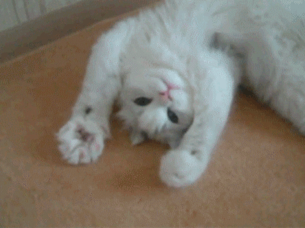

meow

### Data science assignment 4

```r
# install.packages("tidyverse")
library(tidyverse)

metadata <- read.table(file="c:/Users/Jawairia/Documents/MICB425_portfolio/Saanich.metadata.txt", header=TRUE, row.names=1, sep="\t", na.strings="NAN")
otu= read.table(file="c:/Users/Jawairia/Documents/MICB425_portfolio/saanich.otu.txt", header=TRUE, row.names=1, sep="\t", na.strings="NAN")
# source("https://bioconductor.org/biocLite.R")
# biocLite("phyloseq")

library(phyloseq)

load("phyloseq_object.RData")
```

#### Exercise 1

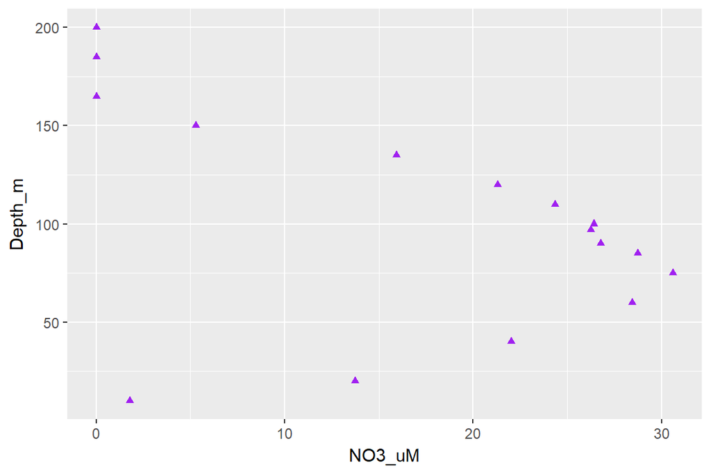

```r
#Figure 1: Plotting NO3_uM against depth
ggplot(metadata, aes(x=NO3_uM, y=Depth_m)) +
  geom_point(shape=17, color="purple")
```

#### Exercise 2

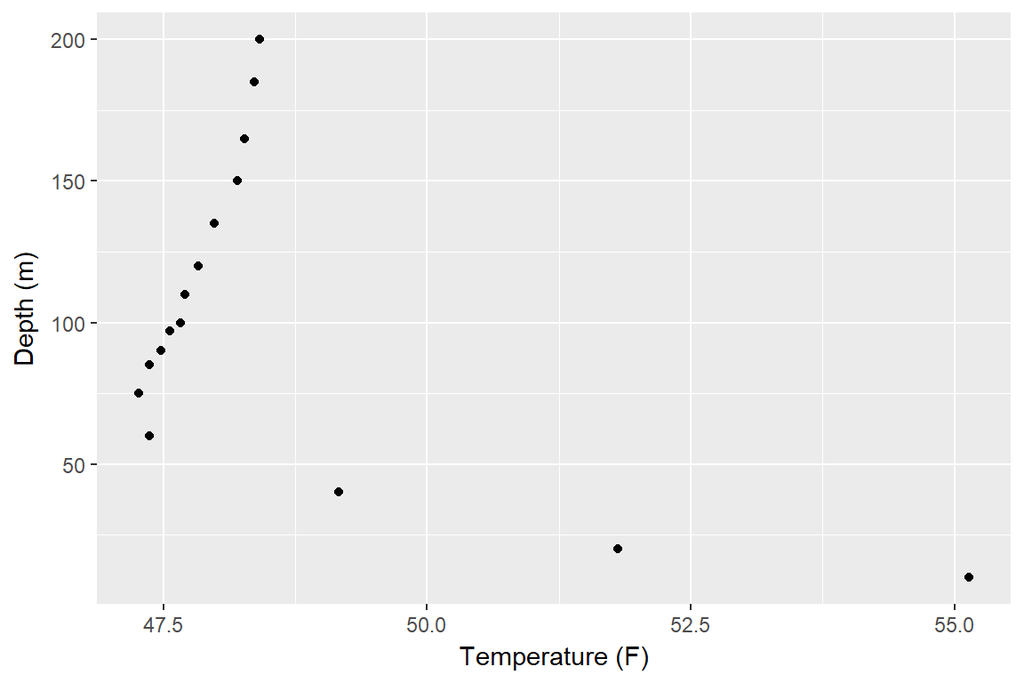

```r
#Figure 2:
metadata %>%
  mutate(Temperature_F = Temperature_C*1.8 +32) %>%
  ggplot() + geom_point(aes(x=Temperature_F, y=Depth_m))+
  labs(x= "Temperature (F)", y="Depth (m)")
```

#### Exercise 3

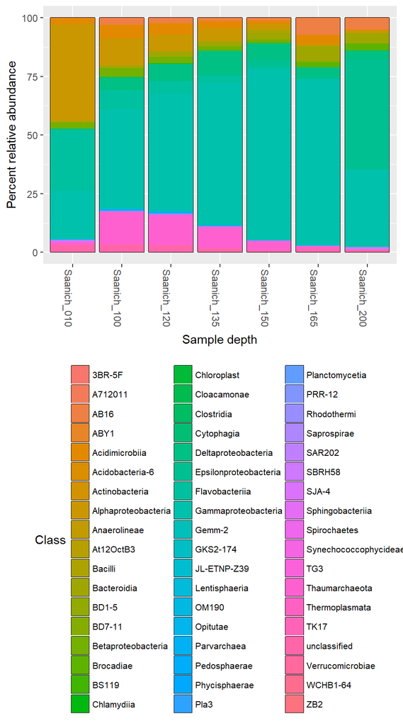

```r
#Figure 3:
physeq_percent = transform_sample_counts(physeq, function(x) 100 * x/sum(x))
  plot_bar(physeq_percent, fill="Class") +
  geom_bar(aes(fill=Class), stat="identity") + labs(x="Sample depth", y="Percent relative abundance")+
    theme(legend.position = "bottom" ,  legend.text=element_text(size=8), plot.title = element_text(size=12, face="bold", hjust=0.5), axis.text= element_text(size=9))+
  guides(fill=guide_legend(ncol=3,bycol=TRUE))
```

#### Exercise 4

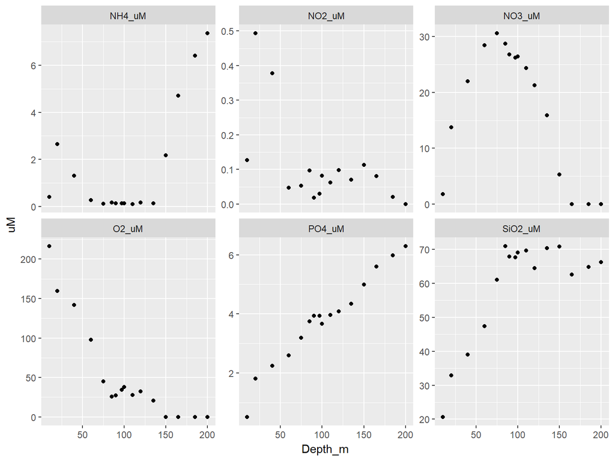

```r
#Figure 4:
library(tidyverse)
metadata %>%
  select(Depth_m, O2_uM, PO4_uM, SiO2_uM, NO3_uM, NH4_uM, NO2_uM) %>%
  gather("Nutrients","uM", O2_uM:NO2_uM)%>%
  ggplot() + geom_point(aes(x=Depth_m, y=uM)) +
  facet_wrap(~Nutrients, scales="free_y") +
  theme(legend.position="none")
```

## Origins and Earth Systems

### Evidence worksheet 01

Paper: [Whitman *et al* 1998](https://www.ncbi.nlm.nih.gov/pmc/articles/PMC33863/)

#### Learning objectives

Describe the numerical abundance of microbial life in relation to ecology and biogeochemistry of Earth systems.

#### What were the main questions being asked?

The main questions were:

- To determine the number of prokaryotes in different habitats and how much they contribute to the total number of microbes on Earth.
- What are the turnover rates of the microbes in these environments and which habitats are the most productive?
- What is the total amount of cellular carbon and other nutrients (N, P) produced by these prokaryotes on earth?
- Estimate prokaryotic diversity in different habitats.

#### What were the primary methodological approaches used?

- Pooling data from studies in which there is sampling of prokaryotes from different habitats, and quantification of cells in these samples and extrapolation, estimations, assumptions, mathematical formulas to calculate cell numbers, nutrient contents etc.:
- Soil: +estimating prokaryotic abundance in differant habitats
  - ocean below 200m
    - average cellular density and multiplied it with the estimated amount of marine and fresh water quantities
  - different soils
    - estimations cellular density from direct cell counts from different soils in past field studies.
    - calculate number of microbes by looking at perviously estimated amounts of soil on earth
  - terrestrial subsurface in various dephts
    - estimated prokaryotic numbers from ground water based on values of several sites, and multiplied this using the estimated value of ground water on Earth.
    - looked at the average porosity of Earth’s soil and used known values of space occupied by prokaryotes in these pores
  - Animals and other habitats
    - human: skin surface area multiplied by cell density of prokaryotes on the skin
      - insects: using termites as a model: multiple number of microbes in insect by total number of insect on the planet.
      - leaves: leaf area x assumed dense population of microbes
      - air: pre-calculated data used

#### Summarize the main results or findings.

3 habitats contribute to prokaryotic abundance on Earth. + Open ocean: 1.2x 10<sup>29</sup> cells + Soil: 2.6x 10<sup>29</sup> cells + Subsurfaces: terrestrial and marine: 0.25-2.5x 10<sup>30</sup> cells

Other important habitas: + Animals, leaves, air, groundwater Further important habitats but with minor contributions to total cell number:

Total number of prokaryotes on earth: + ~4-6x 10<sup>30</sup> cells

Total amount of Carbon in prokaryotes: 350-550 Pg which is roughly 60-100% of the total Carbon of plants

Total prokaryotic nutrients (N,P)= 10x nutrient content of plants. (N: 85-130 Pg, P: 9-14 Pg)

Turnover rates for the different habitats:  
+ soil: 2.5 years + Ocean above 200m: 6-25 days  
+ Ocean below 200m: 300 days  
+ Terrestrial subsurface: 1-2x 10<sup>3</sup> years

cellular productivity: # of cells produced per a unit of time: + Ocean above 200m: highest productivity: 8.2*10<sup>29</sup> cells/year + Total Earth: 1.7x 10<sup>30</sup> cells/year

The higher the cellular productivity: the more mutation events occur: leads to more diversity. This leads to the emergence of new cycles and pathways.

Authors mention that the number of prokaryotic species may be underestimated due to inadequate sampling methods.

#### Do new questions arise from the results?

- Subsurface prokaryote turnover rate: very high: is this an over-estimation: need to investigate this habitat further.
- Since the 1980s tools to study microbial diversity have evolved: do they give us better estimates for the above measurements?
- In the lsat 40 years, has the microbial abundance and diversity changed?
- How does the abundance of the prokaryotes in these environments play a role in the total metabolic capcity of these microbes in affecting the global nutrient cycles?

#### Were there any specific challenges or advantages in understanding the paper (*e.g.* did the authors provide sufficient background information to understand experimental logic, were methods explained adequately, were any specific assumptions made, were conclusions justified based on the evidence, were the figures or tables useful and easy to understand)?

It was hard to understand where some of the numbers, calculations and assumptions came from because it was not very well explained. A discussion on the precision of the data presented in this paper would have been cool.

### Problem set 01

Paper: [Whitman *et al* 1998](https://www.ncbi.nlm.nih.gov/pmc/articles/PMC33863/)

#### Learning objectives:

Describe the numerical abundance of microbial life in relation to the ecology and biogeochemistry of Earth systems.

#### Specific questions:

#### What are the primary prokaryotic habitats on Earth and how do they vary with respect to their capacity to support life? Provide a breakdown of total cell abundance for each primary habitat from the tables provided in the text.

Open ocean: Total 1.2x 10<sup>29</sup> cells

- Top 200m: 3.6x 10<sup>28</sup>
- Below 200m (+10 cm of marine sediment): 8.2x 10<sup>28</sup>

#### What is the estimated prokaryotic cell abundance in the upper 200 m of the ocean and what fraction of this biomass is represented by marine cyanobacterium including Prochlorococcus? What is the significance of this ratio with respect to carbon cycling in the ocean and the atmospheric composition of the Earth?

Upper 200m of the ocean contains a total 3.6 x 10^28 cells:

->2.9x 10<sup>27</sup> autotrophs (e.g, cyanobacteria like Prochlorococcus): 8% of total: responsible for carbon assimilation to sustain C requirements of heterotrophic (comprising 92% of total cells) cells. This menans that the carbon in the ocean is cycled within the ocean at higher rates than the carbon from the atmoshpere is fixed. This essentially results in a loss of carbon from the ocean into the atmosphere.

#### What is the difference between an autotroph, heterotroph, and a lithotroph based on information provided in the text?

- Autotroph: Fix inorganic carbon (CO_2) -> biomass.
- Heterotroph: use organic carbon to build biomass
- Lithotroph: inorganic substances as electron donor like NH3

#### Based on information provided in the text and your knowledge of geography what is the deepest habitat capable of supporting prokaryotic life? What is the primary limiting factor at this depth?

4km below the surface (4 km below terrestrial surface or marine sediments) is the deepest that life has been measured. The main limiting factor for life at this depth is temperature: * temperature is about 125 deg celcius: limit for prokaryotic life. * temperature drops at 22 degrees per km of sruface: Marian’s trench, at 10.9 km deep, is the deepest part of the ocean that can support like: another 4 km below the marine sediments of Marian’s trench would also contain life.

#### Based on information provided in the text your knowledge of geography what is the highest habitat capable of supporting prokaryotic life? What is the primary limiting factor at this height?

Spores can survivee at altitudes up to 77km above the surface of the earth. But metabollically active cells can only survive at roughly 20 km above the surface of the earth (so highest would be: Mt. everest: 8.8km + 20 km on top). Limiting factor: cold temperatures, ionizing radiationm lack of nutrients and no pressure.

#### What is the relationship between carbon content, carbon assimilation efficiency and turnover rates in the upper 200m of the ocean? Why does this vary with depth in the ocean and between terrestrial and marine habitats?

- the net productivity in the ocean is: 51 Pg C/year
- Total amount of marine C in ocean: 0.7-2.9 Pg
- calculating the upper limit (2.9 Pg C)
  - Carbon in one cell: 5-20 fg C/cell
  - 20 fg C/cell=20x0<sup>-30</sup> petagreams C
  - 3.6*10<sup>28</sup> cells x 20x 10<sup>-30</sup> pg/cell= 0.72 Pg of C in marine prokaryotes
  - Carbon efficieny while 20% (a factor 5 needed), Authors used 4 in the paper for some reason:
  - 4 x 0.72 Pg = 2.88Pg/year
- 85% of net productivity in the ocean is consumed in the upper 200 m: 51 Pg C/year X 0.85 = ~43 Pg C/year
  - Turnovers per year in upper 200 m of ocean: 43 pg/yr / 2.88 pg/yr (turnover rate/total amounf of carbon in the ocean)= 14.9 Turnovers per year
  - So: (14.9 turnovers/year) x (1 year/365 days) = one turnover every 24.5 days. or using the lower limit of C in the ocean: 61 turnovers per eyara ax.

The relationship between carbon assimilation efficiency adn turnover rate with depth varies in different environments varies because the primary producer fraction of prokaryotes reach different depths in different habitats.

#### How were the frequency numbers for four simultaneous mutations in shared genes determined for marine heterotrophs and marine autotrophs given an average mutation rate of 4 x 10<sup>-7</sup> per DNA replication? (Provide an example of the calculation with units. Hint: cell and generation cancel out)

- average mutation rate per DNA replication: 4 x 10<sup>-7</sup> (mutations/gerneration)
- for 4 simultaneous mutations: (4 x 10<sup>-7</sup>)<sup>4</sup> = 2.56 x 10<sup>-26</sup> mutations per gene per generation  
  *16 turnovers/day: 22.5turnovers/year
- 3.6 x 10<sup>28</sup>cells (total number of marine cells) x 22.8 turnovers per year = 8.2 x 10<sup>29</sup> cells produced per year
- (8.2 x 10<sup>29</sup> cells per year) x (2.56 x 10<sup>-26</sup> mutations per generation) = 2.1 x 10<sup>4</sup> times per year 4 simulataneous mutations happen
  - 1/[(2.1 x 10<sup>4</sup> events/ year) * (1 year/365 days) * (1 day /24 hours)]= 2.5 events/hour: or in other words
  - four simoultanous mutations happen every 0.4 hours every 24 minutes.

#### Given the large population size and high mutation rate of prokaryotic cells, what are the implications with respect to genetic diversity and adaptive potential? Are point mutations the only way in which microbial genomes diversify and adapt?

Due to high mutation rates and a large population size, the adaptive potential might be much higher than previously thought. The number of prokaryotic species might be much higher than previously estimated. The high diversity implies that prokaryotic cells have the potential to evolve and adapt relatively quick. High mutation rates might allow cells to adapt quickly to changing environments and new metabolic cycles can emerge that might have a great impact on the global nutrient cycle.

Beyond point mutations, microbes can diversify with bigger earrangements in the genome like inversions and deletions. Furthermore, genes can be adopted into the cells from DNA rom neighbouring cells or the environment in a process known as horizontal gene transfer.

#### What relationships can be inferred between prokaryotic abundance, diversity, and metabolic potential based on the information provided in the text?

prokaryotic abundance correlates with magnitude of meetabolic potential.

prokaryotic diversity correlates with diversity of metabolic characteristics.

In conclusion: microbes have a large potential to participate in and alter the earth’s biogeochemical cycles.

### Evidence worksheet 02: Life and the Evolution of Earth’s Atmosphere

Paper 1: [Nisbet et al. 2001](https://www.nature.com/articles/35059210) Paper 2:

[Kasting et al. 2002](http://science.sciencemag.org/content/296/5570/1066)

#### Learning objectives:

Comment on the emergence of microbial life and the evolution of Earth systems

#### Indicate the key events in the evolution of Earth systems at each approximate moment in the time series.

**Hadean:**

- 4.6 Ga:
  - Formation of solar system:
  - Earth: Atmosphere comprises of: water vapor, methane, ammonia, hydrogen, nitrogen.
- 4.5 Ga:
  - Moon formed: gave Earth its spin, tilt, and day/ night cyles and seasons.
- 4.5 Ga - 4.1 Ga:
  - High levels of CO_2: increased temperature despite the sun being weak
- 4.4 Ga:
  - Oldest zircoin forms
  - Oceans, and atmosphere forms
- 4.4- 4.1 Ga:
  - meteorite impacts
- 4.3-3.8 Ga: Heavy bombardment of Earth
- 4.1 Ga:
  - First evidence of life in zirocns and from preserved Carbon isotopes
- 4.0 Ga: Plate subduction
  - Oldest rock: acasta gneiss in Canada and evidence of plate subduction.
  - CO_2 converted to carbonate: and lcts less as greenhouse gas: temperatures become glacial.

**Archaean:**

- 3.8 Ga:
  - Oldest sedimentary rocks show evidence of life and methanogenesis from carbon isotopes.
- 3.5 Ga:
  - Evidence for photosynthesis: in fossils, and stromatolites.
  - Rubisco: enzyme for carbon assimilation detected: cyanobacteria photosynthesize: oxygen being produced.
- 3 Ga:
  - first Glaciation event: Oxygen production leads to less methanogen production.- less greenhouse effect
- 2.7 Ga:
  - great oxydation event-> glaciation
  - Fossils contain molecules that suggest presence of cyanobacteria (hydrocarbon biomarkers) but also eukaryotes (steranes)
- 2.2 Ga:
  - red rock beds obserevd: evidence of oxidation: oxygens level increased sharply.

**Proterozoic:**

- 1.8 Ga:
  - Evidence of eukaryotes.
  - Changing carbon cycle
- 1 Ga:
  - First major ice age has a large impact on carbon cycle

**Phanerozoic:**

- 540 Ma:
  - Cambrian explosion: expansion of multicellular life
  - Emergence of animals.
- 400 Ma:
  - Land plants observed
  - Strong increased oxygenation of atmosphere
  - Denovian extinction:
- 250 Ma:
  - Permian extinction (95% of species disappear)
  - gigantism of organisms, rise of dinosaurs
  - Pangea forms, dry, harsh climate
- 66 Ma:
  - Cretaceous-palogene extinction event
  - Dramatic global warming
  - Dominating forest
- 200,000 years ago:
  - *Homo sapiens* appears

#### Dominant physical/ chemical characteristics of Earth systems

**Hadean** + High CO_2 levels (in the atmosphere) keep the earth warm: 500 deg Celcius + Loss of hydrogen to space + weak sun + Earth mostly molten rock + Rock vapour atmosphere + heavy meteror bombardment + Evidence of plate subduction near the end of the period

**Archean**  
+ Atmosphere failled with methane: keeps the earth warm: methanogenesis + Earth still anoxic at the beginning. + Earth starts cooling + Rock formation + As photosynthesis evolved, some O2 was present

**Proterozoic** + Oxygen levels in atmosphere rising + oxygen reacts with atmospheric methan to produce CO_2 + atmospheric oxygen level rise resulting in glaciation events. + oxic air

**Phanerozoic**

- Formation of pangea and subsequent breaking apart of pangea
- Ice agaes
- Modern atmosphere with increased oxygen levels.
- Emergence of complex global nutrient cycles

### Problem set 2: Microbial Engines

[Falkowski et al. 2008](https://www.ncbi.nlm.nih.gov/pubmed/18497287)

#### What are the primary geophysical and biogeochemical processes that create and sustain conditions for life on Earth? How do abiotic versus biotic processes vary with respect to mattern and energy transformation and how are they interconnected?

[output not shown]

#### Why is Earth’s redox state considered an emergent property?

The Earth’s redox state depends on the biogeochemical cycles: feedback between between the evolution of microbial metabolic and geochemical processes is responsible for defining the average redox conditions of the oceans and atmosphere. An emergent property is something that as a whole is greater than the sum of its parts. The redox state of the planet of the Earth emerges from the combination of many different metabolic processes and reactions catalyzed by different organisms making it an emergent property.

#### How do reversible electron transfer reactions give rise to element and nutrient cycles at different ecological scales? What strategies do microbes use to overcome thermodynamic barriers to reversible electron flow?

A cycle, to be self-sustaning, must have both forward and reverse reactions. Communities of microbes living together interact with each through the transfer of elextrons via the exchange of metabolites, nutrients and wastes. The thermodynamic properties of a reaction is dependent on reaction conditions and organisms that contain thermodynamic conditions that are facored in these conditions can thrive. Synergistic cooperation between different species in the commpunity allow microbes to work together to overcome thermodynamic barriers to reversible electron flow. Reverse reractions can become possible when substrates become very low in concentrations. For example, the reduction of CO2 to methane using H_2 if the hydrogen pressure is low enough, the reverse reaction becomes thermodynamically favorable. The lowest H_2 concentration would potentially be adjacent to the H_2 utilizing, CO_2 reducing cells. On another scale, the reversible pathways may be catalyzed in a more global manner.

#### Using information provided in the text, describe how the nitrogen cycle partitions between different redox “niches” and microbial groups. Is there a relationship between the nitrogen cycle and climate change?

Nitrogen fixation allows for the conversion of N<sub>2</sub> into NH<sub>4</sub> allowing the element to become accessible for anaerobic and metabolic processes. However, the enzymes responsible for this process is inhibited by O<sub>2</sub>. In the presence of O<sub>2</sub>, NH<sub>4</sub> is oxidized to nitrate (thrugh nitrite) by a different set of nitrifying organisms. These nitrifiers concurrently perform these reactions to reduce CO<sub>2</sub> into organic matter. In the absencce of oxygen, microbes may use NO2 and NO3 as electron acceptors in anaerobic oxidation which forms N<sub>2</sub>, thus clsing the nitrogen cycle. This closes the nitrogen cycle. Many different microbial groups are involved in different parts of the nitrogen cycle. Nitrifiers also reduce CO<sub>2</sub> to organic matter. CO<sub>2</sub> contributes to global warming and climate change. This links the nitrogen cycle to climate change.

#### What is the relationship between microbial diversity and metabolic diversity and how does this relate to the discovery of new protein families from microbial community genomes?

Fast turnover rates and large numbers of microbial cells leads to an enormous genetic diversity due to an accumulation of muutations and by acquisition of new genes through orizontal gene transfer. Differenet selective pressures exist in different environments which favor microbes that are capable of utilizing the available substrates. Specialized metabollic pathways arise in these environmetns as a result of the selective pressure and high genetic diversity. Throughout the world, in its myriad collection ofenvironments and selective pressures leads to huge metabolic diversity of microbes. Studies have found that the number of protein families within individual microbial genomes depedns linearly on the number of genes per genome.

#### On what basis do the authors consider microbes the guardians of metabolism?

Metabolic pathways in microbes have core genes like Rubisco in photoshynthesis. These genes are transferred bth vertically and horizontally to different microbes through strong environmental perturbations into various geological landscapes. Individual taxonomic groups may be sleced against but core metabolic machinery cotinues to survive through these environmental stresses. As a community, different organisms can provide different reactions that make-up a whole metabolic pathway. These different organisms are so well adapted to their environment, and so well distributed in different microbes that these metabolic pathways are unlikely to all go extinct. Even when less specialized microbes go extinct in a certain environment, the core metabolic gene set survives due to the varying envuronments and global distribution of enzymes.

### Evidence Worksheet 03: Canfield DE et al. 2010. Science, Rockstrom J et al. 2009 Nature, OR Waters CN et al. 2016. Science

[Rockstrom et al. 2009](https://www.nature.com/articles/461472a)

#### Evaluate human impacts on the ecology and biogeochemistry of Earth systems

#### What were the main questions being asked?

Without pressure from humans, the Holocene, the period of geolical stabilty that we are experiencing now, is expected to continue for at least several thousand more years: What are the planerary boundaries that must not be transgressed in order to prevent the irreversible damage to the earth’s systems that keeps the planet in the Holcene?

#### What were the primary methodological approaches used?

defining planetary boundaries: safe operating space for humanity with respect to the Earth’s biogeochemical and biophysical systems: + quantitaively defined as critical values for one or more control variables greater than which, human life and development become difficult to sustain (e.g. CO<sub>2</sub> concentrations) + control variables that must have thresholds before unacceptable environmental changes soccur: + **Climate change** + boundary: containing rise in gobal mean temperature to no more than 2 deg C above the pre-inustrial level. based on 2 control variables: + atmospheric CO<sub>2</sub> concentrations + radiation: the rate of energy vchange per unit area of the globe as measured at the top of the atmosphere. + **Rate of bidiversity loss** + control variable: species loss + **interference with the N and P cycles** + control variable: rate of N2 removal from atmosphere and rate of N2 fixation. + stratospheric ozone depletion + ocean acidification + global freshwater use + Change in land use + Chemical pollution + Atmospheric aerosol loading +normative and conservative, risk averse approach to quantifying planetary boundary: taking into account large uncertainties that surround the true position of the threshold.

#### Summarize the main results or findings.

The boundaries of the safe operating space for humans has already been exceeded in three systems all due to human interference: + rate of biodiversity loss: + spcies are going extinct at a rate not seen since the lsat global mass-extinction event + Fossil data: background extinction rate for marine life: 0.1-1 million species per year background extinction rate for mammals: 0.2-0.5 extinctions per million species per year. + estimated rate of extinction today: 100-1000x more than what would be considered normal (although this is a preliminary data as background extinction rate measurements aren’t super confident): 30% mammals will be extinct by 2100 at this rate. Main reason: human activities like: + change in land use: urbanization and agriculture in natural ecosystems + Introduction of foreign species into new envionemts + change in distribution and patterns of wildfire occurance. + preserveration biodiversity linked with keeping ecosystems stable and resilient: the more redundnat and complicated a system: the more resilient it is +

[output not shown]

Small changes in the Earth’s biogeochemical and biophysical systems add up and through positive feedback loops: the situtation is exacerbated in the long term.

The different processes listed above are all interconnected in perturbation in one system is often accompanied by perturbations in other systems.

Fast approaching boundaries of three other Earth-system processes: + global freshwater use + change in land use + ocean acidification

Some of the data presented in the paper are preliminary results but the evidence so far suggests that remaining below the proposed thresholds for the above processes will allow humans the freedom to continue to pursue long-term social and economic development as they have been since the onset of the Industrial revolution.

#### Do new questions arise from the results?

What kind of advice do the authors or other experts in the field hve to undo the damage that has already been done?

Are there any boundaries that we are unaware of that is being crossed?

In what ways can the metabolic capacity of microbes be harnessed to reverse some of these changes and to prevent further damage to the Earth’s biogeochemial stability?

#### Were there any specific challenges or advantages in understanding the paper (e.g. did the authors provide sufficient background information to understand experimental logic, were methods explained adequately, were any specific assumptions made, were conclusions justified based on the evidence, were the figures or tables useful and easy to understand)?

No real discussion of methods; it’s more like a review. It was easy to understand and the figures were easy to follow and really helped me understand the massive impact both human activities and microbial metabolism has on determining the Earth’s biogeochemical and geological state.

### Module 1 essay

“Microbial life can easily live without us; we, however, cannot survive without the global catalysis and environmental transformations it provides.”

1.Johan Rockström, Will Steffen, Kevin Noone, Åsa Persson, F. Stuart Chapin III, Eric F. Lambin, Timothy M. Lenton, Marten Scheffer, Carl Folke, Hans Joachim Schellnhuber, Björn Nykvist, Cynthia A. de Wit, Terry Hughes, Sander van der Leeuw, Henning Rodhe, Sverker Sörlin, Peter K. Snyder, Robert Costanza, Uno Svedin, Malin Falkenmark, Louise Karlberg, Robert W. Corell, Victoria J. Fabry, James Hansen, Brian Walker, Diana Liverman, Katherine Richardson, Paul Crutzen & Jonathan A. Foley. 2009. ‘A safe operating space for humanity’, Nature, 461, 472-475 [Rockstrom et al. 2009](https://www.nature.com/articles/461472a)

2.Falkowski, P. G., T. Fenchel, and E. F. Delong. 2008. ‘The microbial engines that drive Earth’s biogeochemical cycles’, Science, 320: 1034-9.  
[Falkowski et al. 2008](https://www.ncbi.nlm.nih.gov/pubmed/18497287)

3. Whitman WB, Coleman DC, and Wiebe WJ. 1998. Prokaryotes: The unseen majority. Proc Natl Acad Sci USA. 95(12):6578-6583.  
   [Whitman et al. 1998](https://www.ncbi.nlm.nih.gov/pmc/articles/PMC33863/)
4. Kasting, J. F., and J. L. Siefert. 2002. ‘Life and the evolution of Earth’s atmosphere’, Science, 296: 1066-8.  
   [Kasting et al. 2002](http://science.sciencemag.org/content/296/5570/1066)
5. Nisbet, E. G., and N. H. Sleep. 2001. ‘The habitat and nature of early life’, Nature, 409: 1083.  
   [Nisbet et al. 2001](https://www.nature.com/articles/35059210)

### Module 01 references

Whitman WB, Coleman DC, and Wiebe WJ. 1998. Prokaryotes: The unseen majority. Proc Natl Acad Sci USA. 95(12):6578-6583.  
[Whitman et al. 1998](https://www.ncbi.nlm.nih.gov/pmc/articles/PMC33863/)

Falkowski, P. G., T. Fenchel, and E. F. Delong. 2008. ‘The microbial engines that drive Earth’s biogeochemical cycles’, Science, 320: 1034-9.  
[Falkowski et al. 2008](https://www.ncbi.nlm.nih.gov/pubmed/18497287)

Kasting, J. F., and J. L. Siefert. 2002. ‘Life and the evolution of Earth’s atmosphere’, Science, 296: 1066-8.  
[Kasting et al. 2002](http://science.sciencemag.org/content/296/5570/1066)

Nisbet, E. G., and N. H. Sleep. 2001. ‘The habitat and nature of early life’, Nature, 409: 1083.  
[Nisbet et al. 2001](https://www.nature.com/articles/35059210)

Waters, Colin N., Jan Zalasiewicz, Colin Summerhayes, Anthony D. Barnosky, Clément Poirier, Agnieszka Galuszka,  
Alejandro Cearreta, Matt Edgeworth, Erle C. Ellis, Michael Ellis, Catherine Jeandel, Reinhold Leinfelder, J. R. McNeill, Daniel deB. Richter, Will Steffen, James Syvitski, Davor Vidas, Michael Wagreich, Mark Williams, An Zhisheng, Jacques Grinevald, Eric Odada, Naomi Oreskes, and Alexander P. Wolfe. 2016. ‘The Anthropocene is functionally and stratigraphically distinct from the Holocene’, Science, 351.  
[Waters et al. 2016](http://science.sciencemag.org/content/351/6269/aad2622)

[The Washington Post, 12-01-03, ’Spaceship Earth: A new view of envrionmentalism](https://www.washingtonpost.com/national/health-science/spacesh/)

[Canfield et al. 2010](http://science.sciencemag.org/content/330/6001/192)

A. Leopold, 1949, ‘The Land Ethic’, from ‘A Sand County Almanac’

Johan Rockström, Will Steffen, Kevin Noone, Åsa Persson, F. Stuart Chapin III, Eric F. Lambin, Timothy M. Lenton, Marten Scheffer, Carl Folke, Hans Joachim Schellnhuber, Björn Nykvist, Cynthia A. de Wit, Terry Hughes, Sander van der Leeuw, Henning Rodhe, Sverker Sörlin, Peter K. Snyder, Robert Costanza, Uno Svedin, Malin Falkenmark, Louise Karlberg, Robert W. Corell, Victoria J. Fabry, James Hansen, Brian Walker, Diana Liverman, Katherine Richardson, Paul Crutzen & Jonathan A. Foley. 2009. ‘A safe operating space for humanity’, Nature, 461, 472-475 [Rockstrom et al. 2009](https://www.nature.com/articles/461472a)

D. P. Schrag, 2012, ‘Geobiology of the Anthropocene’

Zehnder, 1988, ‘Biology of anaerobic microorganisms’, chapter 1

# Module 2

## Module 02 portfolio check

### Problem set 03

Pre-reading: [Wooley et al. 2010](http://journals.plos.org/ploscompbiol/article?id=10.1371/journal.pcbi.1000667) [Madsen et al. 2005](https://www.ncbi.nlm.nih.gov/pubmed/15864265)

#### How many prokaryotic divisions have been described and how many have no culturedrepresentatives (microbial dark matter)?

[Solden *et al.* 2016](https://www.sciencedirect.com/science/article/pii/S1369527416300558): 89 bacterial phyla and 20 archaeal phyla (classified using SSU rRNA) [Shloss et al 2004](https://www.ncbi.nlm.nih.gov/pmc/articles/PMC539005/): 52 bacterial phyla: 26 of them uncultured [Pace et al. 1997](https://www.ncbi.nlm.nih.gov/pubmed/9115194) : 40 bacterial divisions and 12 archael divsions [Locey et al. 2016](http://www.pnas.org/content/113/21/5970): estimation using ecological scaling laws: 10<sup>12</sup> bacterial species on the plannet [Streit et al 2004](https://www.ncbi.nlm.nih.gov/pubmed/15451504) : estimated 99.8% bacteria on earth unculturable.

#### How many metagenome sequencing projects are currently available in the public domain

and what types of environments are they sourced from?

[Gold database](https://gold.jgi.doe.gov/studies?Study.Metagenomic+Study=Yes&Study.Is+Public=Yes) 1424 metagenomic projects: and 51000 sequences [EBI database](https://www.ebi.ac.uk/metagenomics/projects) 1500 metagenomic projects, and 111000 sequencing data sets stored online

Main environments to be sampled from are those that are hard to culture bactera from: Air, soil, freshwater, marine, waste water, humans/animals, sediment

#### What types of on-line resources are available for warehousing and/or analyzingenvironmental sequence information (provide names, URLS and applications)?

Types of resources: metagenomic assembly, taxonomic binning, quality control, statistial analysis, online data bases to store data, as well as annotation.

[EULER](https://omictools.com/euler-sr-tool) Metagenomic Assembly [MEGAN](http://ab.inf.uni-tuebingen.de/data/software/megan5/download/welcome.html)  
Taxonomic binning [SILVA](https://www.arb-silva.de/) taxonomic binning based on 16s SSU rRNA [KEGG](http://www.genome.jp/kegg/) Annotation, gene ontolog, metabollic pathways [MG_RAST](https://metagenomics.anl.gov/) Gene assigning based on sequence similarity to database [AmpliconNoise](http://nebc.nox.ac.uk/bioinformatics/docs/Ampliconnoise.html)  
quality filtering of sequences of bad quality [NCBI](http://ncbi.nlm.nih.gov/): BLAST, sequencing tools, database to store and submit sequencing data, annotation [UniFrac](http://bmf.colorado.edu/unifrac)  
comparing metagenomes based on phylogeny [EBI metagenoics](https://www.ebi.ac.uk/metagenomics/projects) taxonomic, functional and metagenomic analysis, database to store data.

sources: Wooley et al. 2010 [Dudhagara et. al, 2015](](https://www.ncbi.nlm.nih.gov/pmc/articles/PMC4678780/)

#### What is the difference between phylogenetic and functional gene anchors and how can they be used in metagenome analysis?

Phylogenetic anchors are usually genes that are transferred vertically from parent to progeny and are used to generate phylogenetic trees and to assign taxonomy to bacteria. An example are 16s SSu rRNA

Functional gene anchors are genes that are hallmarks of specific metaollic pathways and allow us to gain a better understanding of the metabollic capacity of the members in a microbial community.

[Barker et al. 2005](http://journals.plos.org/ploscompbiol/article?id=10.1371/journal.pcbi.0010003)

#### What is metagenomic sequence binning? What types of algorithmic approaches are used to produce sequence bins? What are some risks and opportunities associated with using sequence bins for metabolic reconstruction of uncultivated microorganisms?

metagenomic sequencing binning is the process involved in the association of sequening data to genes or taxonomy by building longer sequences from overlapping read.

there are two stategies to this: composition-based binning and similarity-based binning: composition based binning doesn’t use a reference sequence to assemble metagenomes but instead uses the G/C content on frequency of codon usage to do this.

similarity based binning is dependent on taxonomy: reference sequences are used to assign homologs, like by using BLAST. Bias towards known sequences. this method aloows for phylogenetic classification.

the risks of using sequence bins for metabolic reconstruction are many: compositon based-binning is often eror-prone especially when closely related OTUs are seen. Often whole genomes are not covered in the metagenomic sequencing so it is hard to completely talk about the metabolic capacity of different OTUs. incomplete coverage of metagenomes also leads to an incrase in inter-species chimera formation. Also, DNA from the species present at lower abundances is not detected as easily. Some sequences cannot be assigned because they do not match what is already known in the databases.

Opportunities: Get a broad overview of the metagenomic potential of a community. it is fast, efficient and based on algorithms that are constantly improving. These methods are definitely more insightful than culture dependent methods.

#### Is there an alternative to metagenomic shotgun sequencing that can be used to access the metabolic potential of uncultivated microorganisms? What are some risks and opportunities associated with this alternative?

Single Cell sequencing: expensive, and takes a long time. Algorithms associated with this are still being developed. not amplification based so hard to weed out sequencing errors.

Third generation sequencing: Oxford Nanopre, PacBio No amplification needed, long reads and fast but high error rates at this point and concentrated samples are needed.

Functional screens: biochemical not high-throuput but can directly asses metabollic potetnial of a comunity by testinf the ability to utilize specific substrates.

Fluoresence In Situ Hybridization: can look for specific sequence existence in a community: have to look at highly conserved markers Other methods:

Source: Wooley et al, 2010

### Evidence worksheet 04

Reading: [Martinez et al. 2007](https://www.ncbi.nlm.nih.gov/pmc/articles/PMC1838496/)

#### What were the main questions being asked?

Characterizing Photorhodopsin photosystems: structure, function and genetics What are the minimal genetic elements required to compement the photorhodopsin system into E. coli.

#### What were the primary methodological approaches used?

DNA from environment (marine microplankton) -> F plasmid with increased duplication using an L-arabinose induced ORI -> transform into E. coli, look for orange growth on retinal containing and lacking media.-> isolate vectors: transposon mutagenesis -> transform into E. coli again: look for loss of phenotype: transposon sequening of loci with inserted sequence. Light activated PR proton transfer measured using pH in media containing PR containing and PR deficient colonies. ATP synthesis was also measured using controls and using molecules to disrupt ATP synthase or to disrupt mitochondrial membrane impermeability to H+.

#### Summarize the main results or findings.

-Engineering of hetrologous microbes!!! -PR based photosystems can be expressed and function in E. coli without the addition of exogenous retinal. found an operon containing 6 genes involved in beta-carotene and retinal biosyntehsis which was adjacent to the photorhodopsin gene by sequencing. These genes are closely rranged and likely transfer together to other microbes. in E. coli the PR systems are capable of generating a proton gradient potentriating these cells to generate ATP using light (phototrophism). Also seen activation of phosphorylation of ADP by ATP synthase. High abundance of this system in marine environments indicate high levels of horizontal gene transfer.

Also cool: increasing F plasmid number of a single plasmid in bacteria: enhanegene expression: make it easier to screen for + and - phenotpyes.

#### Do new questions arise from the results?

- photorhodopsin and enhanced growth have not been definitively linked but so many microes have this system.

-What other functions might the photo-rhodopsin have in these marine bacteria othere than phototrophy: chemosensory, flagellar motility, nutrient acquisition functions

#### Were there any specific challenges or advantages in understanding the paper (e.g. did the authors provide sufficient background information to understand experimental logic, were methods explained adequately, were any specific assumptions made, were conclusions justified based on the evidence, were the figures or tables useful and easy to understand)?

long and tons of genetic jargon but overall easy to read.

### Module 2 References

Martinez A, Bradley AS, Waldbauer JR, Summons RE, DeLong EF. 2007. Proteorhodopsin photosystem gene expression enables photophosphorylation in a heterologous host. Proc Natl Acad Sci 104:5590-5595. [Martinez et al. 2007](https://www.ncbi.nlm.nih.gov/pmc/articles/PMC1838496/) Madsen EL. 2005. Identifying microorganisms responsible for ecologically significant biogeochemical processes. Nat Rev Microbiol 3:439-446. [Madsen et al. 2005](https://www.ncbi.nlm.nih.gov/pubmed/15864265)

```
Wooley JC, Godzik A, Friedberg I. 2010. A primer on metagenomics. PLoS Comput Biol. [Wooley et al. 2010](http://journals.plos.org/ploscompbiol/article?id=10.1371/journal.pcbi.1000667)
```

Barker D, Pagel M. 2005. Predicting Functional Gene Links from Phylogenetic-Statistical Analyses of Whole Genomes. PLoS Comput Biol 1:e3. [Barker et al. 2005](http://journals.plos.org/ploscompbiol/article?id=10.1371/journal.pcbi.0010003)

Dudhagara P, Bhavsar S, Bhagat C, Ghelani A, Bhatt S, Patel R. 2015. Web Resources for Metagenomics Studies. Genomics Proteomics Bioinformatics 13:296-303. [Dudhagara et. al, 2015](](https://www.ncbi.nlm.nih.gov/pmc/articles/PMC4678780/)

Solden L, Lloyd K, Wrighton K. 2016. The bright side of microbial dark matter: lessons learned from the uncultivated majority. Curr Opin Microbiol 31:217-226. [Solden *et al.* 2016](https://www.sciencedirect.com/science/article/pii/S1369527416300558)

Schloss PD, Handelsman J. 2004. Status of the microbial census. Microbiol Mol Biol Rev 68:686-91. [Schloss et al 2004](https://www.ncbi.nlm.nih.gov/pmc/articles/PMC539005)

Pace NR. 1997. A molecular view of microbial diversity and the biosphere. Science 276:734-40. [Pace et al. 1997](https://www.ncbi.nlm.nih.gov/pubmed/9115194)

Locey KJ, Lennon JT. 2016. Scaling laws predict global microbial diversity. Proc Natl Acad Sci U S A 113:5970-5. [Locey et al. 2016](http://www.pnas.org/content/113/21/5970) Streit WR, Schmitz RA. 2004. Metagenomics - the key to the uncultured microbes. Curr Opin Microbiol 7:492-498. [Streit et al 2004](https://www.ncbi.nlm.nih.gov/pubmed/15451504)

# Module 3

## Module 03 portfolio check

- Problem Set_04
  - Completion status:
  - Comments:
- Evidence worksheet_05
  - Completion status:
  - Comments:
- Writing assessment_03
  - Completion status:
  - Comments:
- Additional Readings
  - Completion status:
  - Comments

### Problem set 04: Fine-scale phylogenetic architecture

#### Learning objectives:

- Gain experience estimating diversity within a hypothetical microbial community

#### Outline:

In class Day 1:

1. Define and describe species within your group’s “microbial” community.
2. Count and record individuals within your defined species groups.
3. Remix all species together to reform the original community.
4. Each person in your group takes a random sample of the community (*i.e.* devide up the candy).

Assignment:

5. Individually, complete a collection curve for your sample.
6. Calculate alpha-diversity based on your original total community and your individual sample.

In class Day 2:

7. Compare diversity between groups.

#### Part 1: Description and enumeration

Loading in the packages that will be used.

```r
#To make tables
library(kableExtra)
```

```r
library(knitr)
#To manipulate and plot data
library(tidyverse)
#Alpha-diversity functions in R
library(vegan)
```

loading Data:

```r
candy_data = data.frame(
  number = c(1,2,3,4,5,6,7,8,9,10,11,12,13,14,15,16,17,18,19,20,21,22,23,24,25,26,27,28,29,30,31,32,33,34,35,36,37,38,39,40,41,42,43,44,45,46,47,48,49,50,51,52),
  name = c("M&Ms_Brown","M&Ms_Red","M&Ms_Blue", "M&Ms_Yellow", "M&Ms_Orange", "MM&Ms_Green","Skittles_Yellow"," âSkittles_Purple", "Skittles_Orange", "Skittles_Green", "Skittles_Red", "Big_circle_Orange", "Big_circle_Green", "Big_circle_Yellow","Big_circle_Red", "Big_circle_Purple", "Red_Strings", "Jolly_Ranchers_Yellow", "Jolly_Ranchers_Green", "Jolly_Ranchers_Orange", "Jolly_Ranchers_Pink", "Jolly_Ranchers_Red", "Hershies","Legos_BlueRectangles", "Legos_BlueSquares", "Legos_PinkRectangles", "Legos_PinkSquares", "Legos_YellowRectangle", "Legos_YellowSquare", "Legos_GreenRectangles", "Wine_gummies_Purple", "Wine_gummies_Orange", "Wine_gummies_Red", "Wine_gummies_Yellow", "Octopus_Orange/Green", "Octopus_Yellow/Pink", "Octopus_Green_Pink", "Octopus_Purple/Yellow", "Swirl_Red", "Swirl_Blue", "Weird_gummies_cola", "Weird_gummies_Cherry", "Weird_gummies_Wine", "Classic_Bear_Red", "Classic_Bear_Purple", "Classic_Bear_Orange", "Classic_Bear_White", "Classic_Bear_Yellow", "Classic_Bear_Green", "sugar_coated_gummies_Red", "sugar_coated_gummies_Pink", "sugar_coated_gummies_Yellow"),
  occurences = c(29,27,64,35,59,28,31,43,42,46,35,5,5,4,2,3,14,27,33,44,38,33,16,3,1,6,1,3,1,2,1,1,2,3,2,2,1,1,1,2,3,1,2,16,16,16,16,18,19,1,1,1)
)
```

Creating a Data Table

```r
candy_data %>%
  kable("html") %>%
  kable_styling(bootstrap_options = "striped", font_size = 10, full_width = F)
```

| number | name | occurences |
| --- | --- | --- |
| 1 | M&Ms_Brown | 29 |
| 2 | M&Ms_Red | 27 |
| 3 | M&Ms_Blue | 64 |
| 4 | M&Ms_Yellow | 35 |
| 5 | M&Ms_Orange | 59 |
| 6 | MM&Ms_Green | 28 |
| 7 | Skittles_Yellow | 31 |
| 8 | âSkittles_Purple | 43 |
| 9 | Skittles_Orange | 42 |
| 10 | Skittles_Green | 46 |
| 11 | Skittles_Red | 35 |
| 12 | Big_circle_Orange | 5 |
| 13 | Big_circle_Green | 5 |
| 14 | Big_circle_Yellow | 4 |
| 15 | Big_circle_Red | 2 |
| 16 | Big_circle_Purple | 3 |
| 17 | Red_Strings | 14 |
| 18 | Jolly_Ranchers_Yellow | 27 |
| 19 | Jolly_Ranchers_Green | 33 |
| 20 | Jolly_Ranchers_Orange | 44 |
| 21 | Jolly_Ranchers_Pink | 38 |
| 22 | Jolly_Ranchers_Red | 33 |
| 23 | Hershies | 16 |
| 24 | Legos_BlueRectangles | 3 |
| 25 | Legos_BlueSquares | 1 |
| 26 | Legos_PinkRectangles | 6 |
| 27 | Legos_PinkSquares | 1 |
| 28 | Legos_YellowRectangle | 3 |
| 29 | Legos_YellowSquare | 1 |
| 30 | Legos_GreenRectangles | 2 |
| 31 | Wine_gummies_Purple | 1 |
| 32 | Wine_gummies_Orange | 1 |
| 33 | Wine_gummies_Red | 2 |
| 34 | Wine_gummies_Yellow | 3 |
| 35 | Octopus_Orange/Green | 2 |
| 36 | Octopus_Yellow/Pink | 2 |
| 37 | Octopus_Green_Pink | 1 |
| 38 | Octopus_Purple/Yellow | 1 |
| 39 | Swirl_Red | 1 |
| 40 | Swirl_Blue | 2 |
| 41 | Weird_gummies_cola | 3 |
| 42 | Weird_gummies_Cherry | 1 |
| 43 | Weird_gummies_Wine | 2 |
| 44 | Classic_Bear_Red | 16 |
| 45 | Classic_Bear_Purple | 16 |
| 46 | Classic_Bear_Orange | 16 |
| 47 | Classic_Bear_White | 16 |
| 48 | Classic_Bear_Yellow | 18 |
| 49 | Classic_Bear_Green | 19 |
| 50 | sugar_coated_gummies_Red | 1 |
| 51 | sugar_coated_gummies_Pink | 1 |
| 52 | sugar_coated_gummies_Yellow | 1 |

#### Part 2: Creating a Collector’s curve

Loading in my sample data.

```r
my_sample = data.frame(
 x=c(1,2,3,4,5,6,7,8,9,10,11,12,13,14,15,16,17,18,19,20,21,22,23,24,25,26,27,28,29,30,31,32,33,34,35,36,37,38,39,40,41,42,43,44,45,46,47,48,49,50,51,52,53,54,55,56,57,58,59,60,61,62,63,64,65,66,67,68,69,70,71,72,73,74,75,76,77,78,79,80,81,82,83,84,85,86,87,88,89,90,91,92,93,94,95,96,97,98,99,100,101,102,103,104,105,106,107,108,109,110,111,112,113,114,115,116,117,118,119,120,121,122,123,124,125,126,127,128,129,130,131,132,133,134,135,136,137,138,139,140,141,142,143,144,145,146,147,148,149,150,151),
  y=c(1,1,1,1,1,1,1,1,1,2,2,2,2,2,2,2,3,3,3,3,3,3,3,3,3,3,3,3,4,4,4,5,5,5,5,5,5,5,5,5,5,5,6,6,6,6,6,7,7,7,7,7,7,7,7,8,8,8,8,8,8,8,9,9,9,9,9,9,9,9,9,9,10,10,10,10,10,10,10,11,11,11,11,11,11,11,11,12,13,14,14,14,14,15,15,15,16,16,16,16,16,16,17,17,17,17,17,17,17,17,17,17,18,18,18,18,18,19,19,19,19,20,20,20,20,21,22,23,24,25,26,27,28,29,29,29,29,29,29,30,30,30,30,31,31,32,32,32,32,33,33)

)
```

Creating the plot.

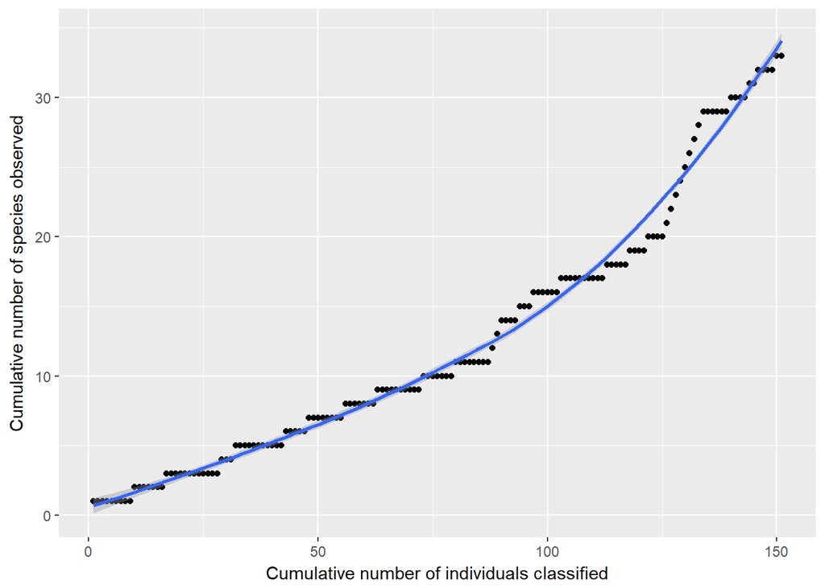

```r
ggplot(my_sample, aes(x=x, y=y)) +
  geom_point() +
  geom_smooth() +
  labs(x="Cumulative number of individuals classified", y="Cumulative number of species observed")
```

- Does the curve flatten out? If so, after how many individual cells have been collected?

The curve produced continues to increase sharply as more cells are classified.

- What can you conclude from the shape of your collector’s curve as to your depth of sampling?

The cap on number of species observed is limited by the sampling size: only about 2/3 of all species have been observed from this small sample

#### Part 3: Diversity estimates (alpha diversity)

##### Diversity: Simpson Reciprocal Index

$\frac{1}{D}$ where $D = \sum p_i^2$

$p_i$ = the fractional abundance of the $i^{th}$ species

```r
species1 = 29/(806)
species2 = 27/(806)
species3 = 64/(806)
species4=35/(806)
species5=59/(806)
species6=28/(806)
species7=31/(806)
species8=43/(806)
species9=42/(806)
species10=46/(806)
species11=35/(806)
species12=5/(806)
species13=5/(806)
species14=4/(806)
species15=2/(806)
species16=3/(806)
species17=14/(806)
species18=27/(806)
species19=33/(806)
species20=44/(806)
species21=38/(806)
species22=33/(806)
species23=16/(806)
species24=3/(806)
species25=1/(806)
species26=6/(806)
species27=1/(806)
species28=3/(806)
species29=1/(806)
species30=2/(806)
species31=1/(806)
species32=1/(806)
species33=2/(806)
species34=3/(806)
species35=2/(806)
species36=2/(806)
species37=1/(806)
species38=1/(806)
species39=1/(806)
species40=2/(806)
species41=3/(806)
species42=1/(806)
species43=2/(806)
species44=16/(806)
species45=16/(806)
species46=16/(806)
species47=16/(806)
species48=18/(806)
species49=19/(806)
species50=1/(806)
species51=1/(806)
species52=1/(806)

1 / (species1^2 + species2^2 + species3^2 + species4^2 + species5^2 + species6^2 + species7^2 + species8^2 + species9^2 + species10^2 + species11^2 + species12^2 + species13^2 + species14^2 + species15^2 + species16^2 + species17^2 + species18^2 + species19^2 + species20^2 + species21^2 + species22^2 + species23^2 + species24^2 + species25^2 + species26^2 + species27^2 + species28^2 + species29^2 + species30^2 + species31^2 + species32^2 + species33^2 + species34^2 + species35^2 + species36^2 + species37^2 + species38^2 + species39^2 + species40^2 + species41^2 + species42^2 + species43^2 + species44^2 + species45^2 + species46^2 + species47^2 + species48^2 + species49^2 + species50^2 + species51^2 + species52^2)
```

```
## [1] 23.44748
```

```r
s1= 9/(151)
s2= 7/(151)
s3= 12/(151)
s4= 3/(151)
s5= 11/(151)
s6= 5/(151)
s7= 7/(151)
s8= 10/(151)
s9= 7/(151)
s10 =8/(151)
s11 =1/(151)
s12 =1/(151)
s13= 4/(151)
s14= 3/(151)
s15= 6/(151)
s16= 10/(151)
s17= 5/(151)
s18= 4/(151)
s19= 4/(151)
s20= 1/(151)
s21= 1/(151)
s22= 1/(151)
s23= 1/(151)
s24= 1/(151)
s25= 1/(151)
s26= 1/(151)
s27= 1/(151)
s28= 8/(151)
s29= 6/(151)
s30= 4/(151)
s31= 2/(151)
s32= 4/(151)
s33= 2/(151)

1/((s1^2) + (s2^2) +(s3^2) + (s4^2) +(s5^2) + (s6^2) +(s7^2) + (s8^2) +(s9^2) + (s10^2) + (s11^2) + (s12^2) +(s13^2) + (s14^2) +(s15^2) + (s16^2) +(s17^2) + (s18^2) +(s19^2) + (s20^2) + (s21^2) + (s22^2) +(s23^2) + (s24^2) +(s25^2) + (s26^2) +(s27^2) + (s28^2) +(s29^2) + (s30^2)+ (s31^2) + (s32^2) +(s33^2))
```

```
## [1] 21.53069
```

- What is the Simpson Reciprocal Index for your sample? 21.53069
- What is the Simpson Reciprocal Index for your original total community? 23.44748

##### Richness: Chao1 richness estimator

$S_{chao1} = S_{obs} + \frac{a^2}{2b})$

$S_{obs}$ = total number of species observed a = species observed once b = species observed twice or more

```r
#my community:
52 + 12^2/(2*40)
```

```
## [1] 53.8
```

```r
#my sample:
33 + 10^2/(2*23)
```

```
## [1] 35.17391
```

- What is the chao1 estimate for your sample? 35.17391
- What is the chao1 estimate for your original total community? 53.8

#### Part 4: Alpha-diversity functions in R

Removing the unnecesary data columns and transposing the data so that `vegan` reads it as a species table with species as columns and rows as samples.

```r
candy_data1_diversity =
  candy_data %>%
  select(name, occurences) %>%
  spread(name, occurences)

candy_data1_diversity
```

```
##    âSkittles_Purple Big_circle_Green Big_circle_Orange Big_circle_Purple
## 1                  43                5                 5                 3
##   Big_circle_Red Big_circle_Yellow Classic_Bear_Green Classic_Bear_Orange
## 1              2                 4                 19                  16
##   Classic_Bear_Purple Classic_Bear_Red Classic_Bear_White
## 1                  16               16                 16
##   Classic_Bear_Yellow Hershies Jolly_Ranchers_Green Jolly_Ranchers_Orange
## 1                  18       16                   33                    44
##   Jolly_Ranchers_Pink Jolly_Ranchers_Red Jolly_Ranchers_Yellow
## 1                  38                 33                    27
##   Legos_BlueRectangles Legos_BlueSquares Legos_GreenRectangles
## 1                    3                 1                     2
##   Legos_PinkRectangles Legos_PinkSquares Legos_YellowRectangle
## 1                    6                 1                     3
##   Legos_YellowSquare M&Ms_Blue M&Ms_Brown M&Ms_Orange M&Ms_Red M&Ms_Yellow
## 1                  1        64         29          59       27          35
##   MM&Ms_Green Octopus_Green_Pink Octopus_Orange/Green
## 1          28                  1                    2
##   Octopus_Purple/Yellow Octopus_Yellow/Pink Red_Strings Skittles_Green
## 1                     1                   2          14             46
##   Skittles_Orange Skittles_Red Skittles_Yellow sugar_coated_gummies_Pink
## 1              42           35              31                         1
##   sugar_coated_gummies_Red sugar_coated_gummies_Yellow Swirl_Blue
## 1                        1                           1          2
##   Swirl_Red Weird_gummies_Cherry Weird_gummies_cola Weird_gummies_Wine
## 1         1                    1                  3                  2
##   Wine_gummies_Orange Wine_gummies_Purple Wine_gummies_Red
## 1                   1                   1                2
##   Wine_gummies_Yellow
## 1                   3
```

Calculating the Simpson Reciprocal Index using the `diversity` function.

```r
diversity(candy_data1_diversity, index="invsimpson")
```

```
## [1] 23.44748
```

```r
#23.44748
```

Calculating the Chao1 richness estimator (and others by default) with the the `specpool` function for extrapolated species richness.

```r
specpool(candy_data1_diversity)
```

```
##     Species chao chao.se jack1 jack1.se jack2 boot boot.se n
## All      52   52       0    52        0    52   52       0 1
```

```r
#    Species chao chao.se jack1 jack1.se jack2 boot boot.se n
#All      52   52       0    52        0    52   52       0 1
```

repeating the calculations for my sample:

```r
my_sample_data = data.frame(
  number = c(1,2,3,4,5,6,7,8,9,10,11,12,13,14,15,16,17,18,19,20,21,22,23,24,25,26,27,28,29,30,31,32,33),
  name = c("M&Ms_Brown","M&Ms_Red", "M&Ms_Blue", "M&Ms_Yellow", "M&Ms_Orange", "MM&Ms_Green","Skittles_Yellow"," âSkittles_Purple", "Skittles_Orange", "Skittles_Green", "Skittles_Red", "Big_circle_Green", "Big_circle_Yellow","Red_Strings", "Jolly_Ranchers_Yellow", "Jolly_Ranchers_Green", "Jolly_Ranchers_Orange", "Jolly_Ranchers_Pink", "Jolly_Ranchers_Red", "Hershies", "Legos_BlueSquares", "Legos_PinkRectangles", "Legos_PinkSquares", "Legos_GreenRectangles", "Wine_gummies_Orange", "Wine_gummies_Yellow", "Octopus_Purple/Yellow", "Swirl_Red", "Classic_Bear_Red", "Classic_Bear_Orange", "Classic_Bear_White", "Classic_Bear_Yellow", "Classic_Bear_Green"),
  occurences = c(9,7,12,3,11,5,8,7,10,7,8,1,1,4,3,6,10,5,4,4,1,1,1,1,1,1,1,1,6,4,2,4,2)
)
my_sample_data %>%
  kable("html") %>%
  kable_styling(bootstrap_options = "striped", font_size = 10, full_width = F)
```

| number | name | occurences |
| --- | --- | --- |
| 1 | M&Ms_Brown | 9 |
| 2 | M&Ms_Red | 7 |
| 3 | M&Ms_Blue | 12 |
| 4 | M&Ms_Yellow | 3 |
| 5 | M&Ms_Orange | 11 |
| 6 | MM&Ms_Green | 5 |
| 7 | Skittles_Yellow | 8 |
| 8 | âSkittles_Purple | 7 |
| 9 | Skittles_Orange | 10 |
| 10 | Skittles_Green | 7 |
| 11 | Skittles_Red | 8 |
| 12 | Big_circle_Green | 1 |
| 13 | Big_circle_Yellow | 1 |
| 14 | Red_Strings | 4 |
| 15 | Jolly_Ranchers_Yellow | 3 |
| 16 | Jolly_Ranchers_Green | 6 |
| 17 | Jolly_Ranchers_Orange | 10 |
| 18 | Jolly_Ranchers_Pink | 5 |
| 19 | Jolly_Ranchers_Red | 4 |
| 20 | Hershies | 4 |
| 21 | Legos_BlueSquares | 1 |
| 22 | Legos_PinkRectangles | 1 |
| 23 | Legos_PinkSquares | 1 |
| 24 | Legos_GreenRectangles | 1 |
| 25 | Wine_gummies_Orange | 1 |
| 26 | Wine_gummies_Yellow | 1 |
| 27 | Octopus_Purple/Yellow | 1 |
| 28 | Swirl_Red | 1 |
| 29 | Classic_Bear_Red | 6 |
| 30 | Classic_Bear_Orange | 4 |
| 31 | Classic_Bear_White | 2 |
| 32 | Classic_Bear_Yellow | 4 |
| 33 | Classic_Bear_Green | 2 |

```r
my_sample_data1_diversity =
  my_sample_data %>%
  select(name, occurences) %>%
  spread(name, occurences)

my_sample_data1_diversity
```

```
##    âSkittles_Purple Big_circle_Green Big_circle_Yellow
## 1                   7                1                 1
##   Classic_Bear_Green Classic_Bear_Orange Classic_Bear_Red
## 1                  2                   4                6
##   Classic_Bear_White Classic_Bear_Yellow Hershies Jolly_Ranchers_Green
## 1                  2                   4        4                    6
##   Jolly_Ranchers_Orange Jolly_Ranchers_Pink Jolly_Ranchers_Red
## 1                    10                   5                  4
##   Jolly_Ranchers_Yellow Legos_BlueSquares Legos_GreenRectangles
## 1                     3                 1                     1
##   Legos_PinkRectangles Legos_PinkSquares M&Ms_Blue M&Ms_Brown M&Ms_Orange
## 1                    1                 1        12          9          11
##   M&Ms_Red M&Ms_Yellow MM&Ms_Green Octopus_Purple/Yellow Red_Strings
## 1        7           3           5                     1           4
##   Skittles_Green Skittles_Orange Skittles_Red Skittles_Yellow Swirl_Red
## 1              7              10            8               8         1
##   Wine_gummies_Orange Wine_gummies_Yellow
## 1                   1                   1
```

```r
diversity(my_sample_data1_diversity, index="invsimpson")
```

```
## [1] 21.53069
```

```r
#21.53069

specpool(my_sample_data1_diversity)
```

```
##     Species chao chao.se jack1 jack1.se jack2 boot boot.se n
## All      33   33       0    33        0    33   33       0 1
```

```r
#    Species chao chao.se jack1 jack1.se jack2 boot boot.se n
#All      33   33       0    33        0    33   33       0 1
```

In Project 1, you will also see functions for calculating alpha-diversity in the `phyloseq` package since we will be working with data in that form.

For your sample:

- What are the Simpson Reciprocal Indices for your sample and community using the R function? community: 23.44748 my Sample: 21.53069
- What are the chao1 estimates for your sample and community using the R function? community:52 my sample:33
  - Verify that these values match your previous calculations: the Simpson Reciprocal Indices are exactly the same, and the chao1 estimates are relatively close.

#### Part 5: Concluding activity

- How does the measure of diversity depend on the definition of species in your samples?

The less stringent your classification scheme, the less species diversity will be seem. If different species definitions lead to the same number of species but different abundance:diversity ratios among the species: this will also affect the diversity calculations

- Can you think of alternative ways to cluster or bin your data that might change the observed number of species?

We could have disregarded colour in our classification scheme: this would drastially reduce the number of species observed and have an effect on diversity calculations

- How might different sequencing technologies influence observed diversity in a sample? Sequencing methods that are error prone like the oxford nan-pore or sanger-sequencing: the observed diversity will likely be overestimated or you would get misclassification of some of our OTUs. Furthermore, more errors in sequencing platforms lead to more diversity in bp in the data collected resulting in an increased amount of diversity in the sample.

### Evidence Worksheet 05: Extensive mosaic structure

reading [Welch et al. 2002](http://www.pnas.org/content/99/26/17020)

#### What were the main questions being asked?

-How do the genomes of different E. coli differ (specifically 3 closely related strains)and how do these differences play a role in the pathogenicity of E. coli strains. -Comparing genome structures of E. coli to understand evolution of E. coli.

#### What were the primary methodological approaches used?

Genome sequence of: uropathogenic E. coli strain CFT073 (from a woman with acute pylonephritis) compared to enterohemorrhagic strain EDL933 and nonpathogenic lab strain MG1655.

Genome sequences analyzed using MAGPIE, and homologs with the other 2 strains were searched for using BLAST: genes with 90% similarity were determined to be orthologues.

#### Summarize the main results or findings.

- The CFT073 genome sequenced and a restriction enzyme map was generated. The genome had no plasmids and had roughly 5500 coding genes. CTF073 has more pathogenicity islands and virulence gens than MG6155 (1.303 Mb!! vs 716 kb). The ori and terminuts of replication between the two strains was identical. In CFT073: the codons used in the pathogenicity island differed from the rest of the gene: indication of horizontal gene transer.

CFT07 has no plasmids and type 3 secretion system while EDL933 does: can give insight into how the pathogenicity of these 2 strains differs. CFT07 genome has fimbial adhesins, recombinases, autotransporters for exporting virulence factors, hemolysi genes that encode cytolytic toxins and contains a pathogenicity island from Yersinia pestis. roughly 40% of all proteins were shared between all 3 strains and CFT07 had 20% of its genome being exclusive to itself. the rest of the genome was shared between only 2 of the 3 strains. Pathogeneic strains definitely more genetially diverse than lab strains because of genes that they pick up from the environment during their foray into the harsh and selective environment of the intestine or urinary regions. The location of the plasmids or pathogenicity islands in the genome of these strains helps define which strain they are.

#### Do new questions arise from the results?

What gene subsets differentiate E. coli that have tissue tropism for different cell types in the himan body?

Does the high sequence similarity critieria become obsolete when talking about assigning taxonomy to species with increasing amounts of horizontal gene transfer as these strains have very different functional capacities from each other?

#### Were there any specific challenges or advantages in understanding the paper (e.g. did the authors provide sufficient background information to understand experimental logic, were methods explained adequately, were any specific assumptions made, were conclusions justified based on the evidence, were the figures or tables useful and easy to understand)?

The method section was not very detailed but in general the paper was okay.

#### Based on your reading and discussion notes, explain the meaning and content of the following figure derived from the comparative genomic analysis of three E. coli genomes by Welch et al. Remember that CFT073 is a uropathogenic strain and that EDL933 is an enterohemorrhagic strain. Explain how this study relates to your understanding of ecotype diversity. Provide a definition of ecotype in the context of the human body. Explain why certain subsets of genes in CFT073 provide adaptive traits under your ecological model and speculate on their mode of vertical descent or gene transfer.

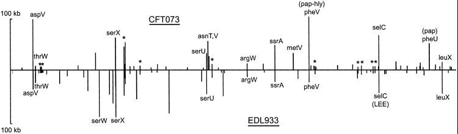

An ectotype is a bacterial strain that is well adapted to a specific ecological niche and is unlikely to be found elsewhere. In other words, it is a genetically distinct geographic variety of organism within a species.In the human body, these geographic locations can be different physical locations like the small intestine, the inguinal region or the urinary tract. Bacteria in these diffrent locations face different selective pressures based on the environmal conditions that are present. Even on a microscopic level, for example, in the gut, bacteria in the center of the intestinal lumen and those closely associated with the microvilli face different pressures. These different ecotypes all share 16s SSU rRNA sequences but must be able to survive different environments and are thus differentially transcriptically active. As a result, different ecotypes can differ significantly in the genetic islands specific for the niche that they occupy.

The figure depicts the different genetic islands in the genomes of the two human pathogenic strains of E. coli. These islands were likely selected for by the different environments and nutrients these bacteria encounter. The backbone of the genome is shared between the two E. coli strains. The backbone genes are likely transfered vertically from parent to progeny but the differential presence of the genetic islands is due to horizontal gene transfer. This leads me to believe that horizontal gene transfer is most likely the key process behind the evolution of ecotypes.

### Module 3 essay

Discuss the challenges involved in defining a microbial species and how HGT complicates matters, especially in the context of the evolution and phylogenetic distribution of microbial metabolic pathways. Can you comment on how HGT influences the maintenance of global biogeochemical cycles through time? Finally, do you think it is necessary to have a clear definition of a microbial species? Why or why not?

Microbes are not capable of sexual reproduction, thus sorting them into species based on their ability to interbreed and generate fertile offsprings does not apply as it does to eukaryotes. Instead, the phylogenetic species concept is more applicable (1). The phylogenetic species concept is based not on processes but on fixed differences between organism (1). Fixed morphological differences have been used to classify microbes, most often in culture, but the issue of bacterial species definition has always been a contentious one (1). Genomics now offers novel insight into intra-species diversity and for the emergence of a more accurate classification system (2). In short, defining a microbial species depends a lot on which species concept is being used. Currently, microbes are most often classified through their genetic characteristics. For example, the 16srRNA sequence is a fairly conserved genetic region, mutations in this region can differentiate species phylogenetically (3). The small subunit rDNA is sequenced and put through an algorithm for estimating species based on genetic distances (4). With the emergence of bacterial genomics, arose the concept that two individual bacteria belong to the same species or operational taxonomic unit (OUT) if their 16srDNA sequence shows 97% or more sequence identity (4). More recently, a method has been developed that defines a bacterial species by amplicon sequence variants (ASV) where individual units in a group must share 100% sequence similarity (3). This method allows for the designation of bacterial species definition at an even higher resolution than OTUS (3). Furthermore, horizontal gene transfer (HGT) makes it harder to establish where certain bacteria belong on the phylogenetic tree and makes it difficult to understand the relationships between lineages (5). HGT is important for the rapid evolution of bacteria that results in the dissemination of key metabolic pathways all over the world but in turn makes taxonomic classification less functionally descriptive and more challenging (6). The challenges associated with defining bacterial species has led some scientists to ask whether having a clear species definition is important. The standard approach in bacterial genomics has been to define microbial species by 97% sequence identity between two individual cells and this has allowed scientists to assign well distinguished taxonomic labels in many cases (4). However there have been some difficulties associated with this method. For example, sometimes two different species like *Shigella* spp. and *E. coli* are often placed in the same group (4). The higher resolution ASV method has allowed bioinformaticians to overcome some of these issues as it is less arbitrary in its species definition but any sequencing errors must be accounted for by laborious de-noising processes that might bias the data (3). Furthermore, by only looking at phylogenetic markers, functional diversity and intra-species variation is often missed. HGT, while not affecting the phylogenetic markers seen in individual microbes has a large impact on the functional markers that are present (6). Even distantly related bacteria can exchange genetic information via conjugation. Phylogenetic classification based solely on one gene make it hard for species to be broken down into subspecies or strains as is the case in *E. coli* strains CTF073, MG6155 and EDL933 (7). All three of these bacteria share at least 97% of their 16s rDNA sequences but have different pathogenic and functional capacities in the human body (7). As such, the phylogenetic classifications based on phylogenetic markers makes it difficult to track intra-species evolution because two species can have very similar 16s rDNA sequences but differ greatly in the bulk of their genome. For example, by sequence one fifth of the CTF07 genome is different from the other *E. coli* strains but the three individual bacteria are still classified as belonging to the same species (6). Recently, new methods like Multi-locus Strain Analysis (MLSA) and Single-Locus Strain Typing (SLST) (8) have allowed researchers to compare genome wide sequences and 16srDNA sequences to find new phylogenetic markers that allow better classification of certain unculturable and hard to distinguish bacteria. MLSA in particular was established to circumvent the negative effects HGT has on defining microbial species and is being considered as an alternative to using single locus markers to get a better understanding of the evolution of diverse ecotypes (8). HGT is important to the maintenance of global biogeochemical cycle through time (6). HGT happens constitutively in the environment between microbes through transformation, transduction, and conjugation (6). This way, the genes for many key metabolic pathways like Rubisco, the enzyme involved in the first step of carbon fixation, get distributed first at a micro-environmental scale and then through the dissemination of microbes at a global scale (6). Selective pressures by or an increased growth advantage in new environments select for the persistence of these metabolic pathways in their new surroundings (6). While HGT makes phylogenetic classification difficult, it allows the global geochemical cycles to be maintained. Due to this reason, some scientists have dubbed microbes as guardians of metabolism (6). This concept entails that even if a key metabolic enzyme was to go extinct in one environment, HGT ensures its survival somewhere else on the planet (6). On a larger scale, HGT plays a key role in maintaining these metabolic enzymes on the planet through time. The challenges associated with defining a bacterial species due to the genomic variability introduced by HGT has lead some scientists to question the necessity for such a concept (2). The bacterial species definition has many practical significances in the identification of microbes, diagnosis of diseases and ecological surveying of diversity. But, the concept has had a hard time moving forward. Although genomics has the potential for the establishment of a better classification system, HGT introduces ambiguity to inter-species relationships and evolution (9). At this point, I think it is not currently necessary to have one universal species definition. First, our knowledge is based off of too few samples and phylogenetic groups and the analyses of this data is often biased towards known or culturable species (2). Furthermore, analyses comparing 16s rDNA and MLSA or culturing techniques have shown that single locus based species classifications do not suitably encompass whole-genome sequence and gene-content diversity (2, 8). For example, *Burkholderia* and *Shewanella* genera, while having tight ecological niches do exhibit intra-species clusters. However, these clustering are not seen through phylogenetic analysis (2). Therefore, the species concept, or the concept that defined and meaningful clusters of diversity that has been so successful in classifying most eukaryotes may not be applicable in the microbial world. If clusters of diversity do exist in the microbial world, they must be studied through methods that consider varying phenotypic and ecological properties as well as genomic dissimilarity (8). Due to HGT and the great genetic variability that is created because of it, an inflexible species definition makes this hard to accomplish. In conclusion, arriving at one specific criteria for defining microbial species faces many challenges. Approaches that attempt to classify microbes based on the sequence similarities of their phylogenetic markers make it difficult to control for the effect HGT has on the functional and ecological properties of these microbes. HGT is important for microbial evolution and allows for the upkeep of metabolic pathways globally. This leads to the maintenance of global biogeochemical cycles. Because of the lack of the functional description associated with defining a microbial species, it might be more useful for researchers to look at different applications in studying microbes and their impact on the planet.

#### References

1. Staley JT. 2006. The bacterial species dilemma and the genomic-phylogenetic species concept. Philos Trans R Soc B Biol Sci 361:1899-1909.
2. Konstantinidis KT, Ramette A, Tiedje JM. 2006. The bacterial species definition in the genomic era. Philos Trans R Soc Lond B Biol Sci 361:1929-40.
3. Callahan BJ, McMurdie PJ, Holmes SP. 2017. Exact sequence variants should replace operational taxonomic units in marker-gene data analysis. ISME J 11:2639-2643.
4. Edgar RC. 2018. Updating the 97% identity threshold for 16S ribosomal RNA OTUs. Bioinformatics.
5. Wooley JC, Godzik A, Friedberg I. 2010. A primer on metagenomics. PLoS Comput Biol.
6. Falkowski PG, Fenchel T, Delong EF. 2008. The Microbial Engines That Drive Earth’s Biogeochemical Cycles. Science (80- ) 320:1034-1039.
7. Welch RA, Burland V, Plunkett G, Redford P, Roesch P, Rasko D, Buckles EL, Liou S-R, Boutin A, Hackett J, Stroud D, Mayhew GF, Rose DJ, Zhou S, Schwartz DC, Perna NT, Mobley HLT, Donnenberg MS, Blattner FR. 2002. Extensive mosaic structure revealed by the complete genome sequence of uropathogenic Escherichia coli. Proc Natl Acad Sci U S A 99:17020-4.
8. Pozzi AC, Bautista-Guerrero HH, Abby SS, Herrera-Belaroussi A, Abrouk D, Normand P, Menu F, Fernandez MP. 2018. Robust Frankia phylogeny, species delineation and intraspecies diversity based on Multi-Locus Sequence Analysis (MLSA) and Single-Locus Strain Typing (SLST) adapted to a large sample size. Syst Appl Microbiol.
9. Fraser C, Alm EJ, Polz MF, Spratt BG, Hanage WP. 2009. The bacterial species challenge: Making sense of genetic and ecological diversity. Science (80- ).

### Module 3 References

1. Staley JT. 2006. The bacterial species dilemma and the genomic-phylogenetic species concept. Philos Trans R Soc B Biol Sci 361:1899-1909. [Staley et al. 2006](https://www.ncbi.nlm.nih.gov/pmc/articles/PMC1857736/)
2. Konstantinidis KT, Ramette A, Tiedje JM. 2006. The bacterial species definition in the genomic era. Philos Trans R Soc Lond B Biol Sci 361:1929-40. [Konstantinidis et al. 2006](https://www.ncbi.nlm.nih.gov/pmc/articles/PMC1764935/)
3. Callahan BJ, McMurdie PJ, Holmes SP. 2017. Exact sequence variants should replace operational taxonomic units in marker-gene data analysis. ISME J 11:2639-2643. [Callahan et al. 2017](https://www.ncbi.nlm.nih.gov/pubmed/28731476)
4. Edgar RC. 2018. Updating the 97% identity threshold for 16S ribosomal RNA OTUs. Bioinformatics. [Edgar et al. 2018](https://www.ncbi.nlm.nih.gov/pubmed/29506021)
5. Wooley JC, Godzik A, Friedberg I. 2010. A primer on metagenomics. PLoS Comput Biol. [Wooley et al. 2010](http://journals.plos.org/ploscompbiol/article?id=10.1371/journal.pcbi.1000667)
6. Falkowski PG, Fenchel T, Delong EF. 2008. The Microbial Engines That Drive Earth’s Biogeochemical Cycles. Science (80- ) 320:1034-1039. [Falkowski et al. 2008](https://www.ncbi.nlm.nih.gov/pubmed/18497287)
7. Welch RA, Burland V, Plunkett G, Redford P, Roesch P, Rasko D, Buckles EL, Liou S-R, Boutin A, Hackett J, Stroud D, Mayhew GF, Rose DJ, Zhou S, Schwartz DC, Perna NT, Mobley HLT, Donnenberg MS, Blattner FR. 2002. Extensive mosaic structure revealed by the complete genome sequence of uropathogenic Escherichia coli. Proc Natl Acad Sci U S A 99:17020-4. [welch et al. 2002](https://www.ncbi.nlm.nih.gov/pubmed/12471157)
8. Pozzi AC, Bautista-Guerrero HH, Abby SS, Herrera-Belaroussi A, Abrouk D, Normand P, Menu F, Fernandez MP. 2018. Robust Frankia phylogeny, species delineation and intraspecies diversity based on Multi-Locus Sequence Analysis (MLSA) and Single-Locus Strain Typing (SLST) adapted to a large sample size. Syst Appl Microbiol. [Pozzi et. al 2018](https://www.sciencedirect.com/science/article/pii/S0723202018301139)
9. Fraser C, Alm EJ, Polz MF, Spratt BG, Hanage WP. 2009. The bacterial species challenge: Making sense of genetic and ecological diversity. Science (80- ). [Fraser et al. 2009](https://www.ncbi.nlm.nih.gov/pubmed/19197054)
10. Madsen EL. 2005. Identifying microorganisms responsible for ecologically significant biogeochemical processes. Nat Rev Microbiol 3:439-446. [Madsen et al. 2005](https://www.ncbi.nlm.nih.gov/pubmed/15864265)